# guia de estudio

# Guía de Estudio: Two Sample t-Test (Comparación de dos medias)

1. ¿Cuándo usar un Two Sample t-Test?

Se usa cuando queremos comparar el promedio (media) de una variable cuantitativa entre dos grupos.

Ejemplos:

- Domestic vs Foreign guests
- Store A vs Store B
- Hombres vs Mujeres
- Método A vs Método B

Ejemplo

Una universidad quiere saber si los estudiantes que toman clases presenciales obtienen, en promedio, calificaciones más altas que los estudiantes que toman clases en línea.

- Grupo 1: Estudiantes presenciales
- Grupo 2: Estudiantes en línea
- Variable: Calificación final del curso
2. Hipótesis

Cola derecha (>)

Cuando sospechamos que un grupo tiene una media mayor.

Ejemplo:

- H0:μd ≤ μf
- Ha:μd > μf

Interpretación:

- Ho: Los huéspedes domésticos no tienen una media mayor.
- Ha: Los huéspedes domésticos sí tienen una media mayor.

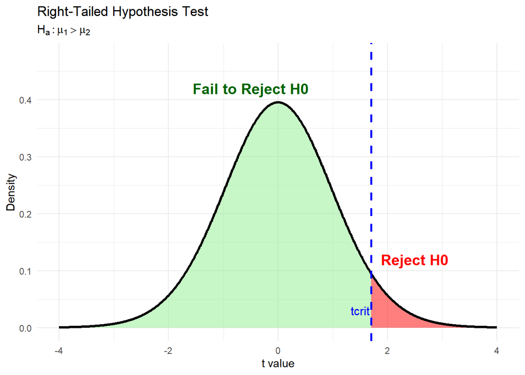

Este gráfico muestra únicamente el concepto:

- 🟩 Área verde = No rechazar H₀.
- 🟥 Área roja = Región de rechazo.
- 🔵 Línea punteada = valor crítico.
- La región roja está a la derecha, por eso es una prueba de cola derecha (>).

Cola izquierda (<)

- H0: μX1 ≥ μX2
- Ha: μX1 < μX2

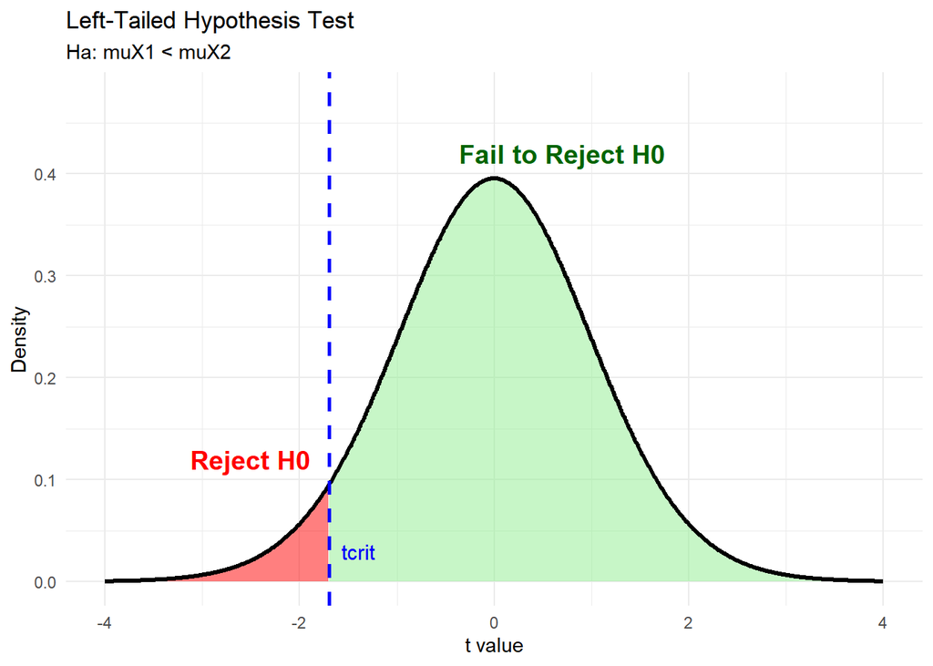

Dos colas (≠)

Cuando solo queremos saber si son diferentes.

- H0: μ1 = μ2
- Ha: μ1 ≠ μ2

Ejemplo:

Store A vs Store B.

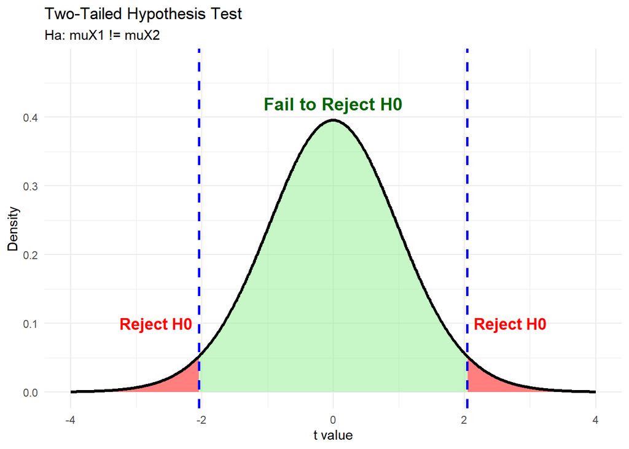

Interpretación:

- 🟥 Cola izquierda = Región de rechazo.
- 🟥 Cola derecha = Región de rechazo.
- 🟩 Centro = No rechazar H₀.
- 🔵 Líneas punteadas = valores críticos.
- Como el rechazo ocurre en ambos extremos, es una prueba de dos colas (!=).
3. Exploratory Analysis

Obtener estadísticas descriptivas

```r
dataframe |>
  group_by(grupo) |>
  summarise(
    mean = round(mean(variable), 1),
    median = round(median(variable), 1),
    sd = round(sd(variable), 1)
  )
```

Debes mirar:

- Mean
- Median
- Standard Deviation

Boxplot

```r
dataframe |>
  ggplot(aes(x = grupo, y = variable)) +
  geom_boxplot()
```

Sirve para comparar distribuciones.

Dot Plot

```r
dataframe |>
  ggplot(aes(x = grupo, y = variable)) +
  geom_jitter(width = 0.2, height = 0)
```

Sirve para visualizar cada observación.

4. Revisar si las varianzas son iguales

Antes de hacer el t-test:

```r
var.test(sample1, sample2,
         alternative = "two.sided")
```

Hipótesis:

- $H0:\sigma_1^2 = \sigma_2^2$
- $Ha:\sigma_1^2 \neq \sigma_2^2$

Decisión:

Si: p-value > 0.05

No rechazamos Ho.

Conclusión:

✅ Las varianzas son iguales.

Entonces:

var.equal = TRUE

Si: p-value < 0.05

Rechazamos Ho.

Conclusión:

✅ Las varianzas son diferentes.

Entonces:

var.equal = FALSE

5. Ejecutar el Two Sample t-Test

Cola derecha

```r
t.test(sample1,
       sample2,
       alternative = "greater",
       var.equal = TRUE)
```

Cola izquierda

```r
t.test(sample1,
       sample2,
       alternative = "less",
       var.equal = TRUE)
```

Dos colas

```r
t.test(sample1,
       sample2,
       alternative = "two.sided",
       var.equal = TRUE)
```

6. Regla de decisión

Nivel de significancia:

$\alpha = 0.05$

Si:

p-value < 0.05

- ✅ Rechazar Ho
- ✅ Apoyar Ha

Si:

p-value > 0.05

- ✅ No rechazar Ho
- ✅ No podemos apoyar Ha
7. Cómo escribir la decisión

*Cuando rechazamos Ho*

Ejemplo:

Decision: The p-value (0.0011) is less than alpha (0.05). Therefore, we reject Ho and support Ha.

Conclusion: There is sufficient evidence that domestic guests give higher average scores than foreign guests.

*Cuando NO rechazamos Ho*

Ejemplo:

Decision: The p-value (0.2221) is greater than alpha (0.05). Therefore, we do not reject Ho.

Conclusion: There is not enough evidence to conclude that the average caffeine content differs between the two stores.

8. Errores Tipo I y Tipo II

Error Tipo I

Ocurre cuando:

✅ Rechazamos Ho

pero

❌ Ho era verdadera.

Recordatorio:

Si rechazaste Ho, el posible error es Tipo I.

Ejemplo:

Concluir que los huéspedes domésticos tienen una media mayor cuando en realidad no la tienen.

Error Tipo II

Ocurre cuando:

✅ No rechazamos Ho

pero

❌ Ha era verdadera.

Recordatorio:

Si NO rechazaste Ho, el posible error es Tipo II.

Ejemplo:

Concluir que las tiendas tienen el mismo promedio de cafeína cuando en realidad sí son diferentes.

9. Effect Size (Cohen’s d)

Paso 1: Calcular la desviación estándar agrupada

```r
sp <- sqrt(
          ((n1-1)*var(sample1) +
          (n2-1)*var(sample2))
          /
          (n1+n2-2)
          )
```

Paso 2: Calcular el tamaño del efecto

```r
abs(mean(sample1)-mean(sample2))/sp
```

Interpretación

| Effect Size | Interpretación |
| --- | --- |
| 0.2 | Pequeño |
| 0.5 | Mediano |
| 0.8 o más | Grande |

Un t-test responde:

- ¿Existe evidencia de una diferencia?

El Effect Size responde:

- ¿Qué tan grande es esa diferencia?